# 5. Dimensionality reduction techniques

In this chapter I study dimensionality reduction techniques. The chapter starts with an introduction to the dataset while the focus is on Principal Component Analysis (PCA). This chapter is divided to data wrangling and analysis.

## Data wrangling and a brief introduction to the data

This section starts with introduction to the data from UNDP and proceeds with some wrangling and cleaning of the data. The data wrangling is included in the “create_human.R” file that can be accessed [here](https://github.com/Vviljo/IODS-project/blob/master/data/create_human.R). To see the code, please use the link. The file includes comments on the steps taken but in short what I do there is the following:

The “human.txt” data created previously is wrangled such that the Gross National Income (GNI) variable is numeric.

Next step here is to exclude unneeded variables such that I keep only the following columns: “Country”, “Edu2.FM”, “Labo.FM”, “Edu.Exp”, “Life.Exp”, “GNI”, “Mat.Mor”, “Ado.Birth”, “Parli.F”. After this, I remove all rows with missing values. Also, as suggested by tail()-function, the “human” dataset includes observations which relate to regions instead of countries, namely the last 7 rows. I remove them from the dataset.

Last things here with respect to the data wrangling are to define the row names of the data by the country names and remove the country name column from the data. The data should now have 155 observations and 8 variables, which I check with str()-function. The new dataset is called “human_” and the corresponding .txt file is called “human.txt” such that the earlier version of “human.txt” is not available anymore although it can be accessed by running only the first part of the “create_human.R” file.

### About the dataset

The data originates from the United Nations Development Programme (see: http://hdr.undp.org/en/content/human-development-index-hdi).

The wrangled version of the dataset consists of 155 observations of 8 variables that are:

- **Edu2.FM** : the ratio of female and male populations with secondary education in each country
- **Labo.FM** : the ratio of labour force participation of females and males in each country
- **Life.Exp** : life expectancy at birth
- **Edu.Exp** : Expected years of schooling (years)
- **GNI** : The gross national income
- **Mat.Mor** :The maternal mortality ratio
- **Ado.Birth** : the adolescent birth rate
- **Parli.F** : the share of parliamentary seats held by women

```r
rm(list=ls())
library(dplyr)
```

```r
library(ggplot2)
library(GGally)
library(tidyr)
library(MASS)
library(corrplot)
human_ <- read.table("human.txt")
str(human_)
```

```
## 'data.frame':    155 obs. of  8 variables:
##  $ Edu2.FM  : num  1.007 0.997 0.983 0.989 0.969 ...
##  $ Labo.FM  : num  0.891 0.819 0.825 0.884 0.829 ...
##  $ Life.Exp : num  81.6 82.4 83 80.2 81.6 80.9 80.9 79.1 82 81.8 ...
##  $ Edu.Exp  : num  17.5 20.2 15.8 18.7 17.9 16.5 18.6 16.5 15.9 19.2 ...
##  $ GNI      : int  64992 42261 56431 44025 45435 43919 39568 52947 42155 32689 ...
##  $ Mat.Mor  : int  4 6 6 5 6 7 9 28 11 8 ...
##  $ Ado.Birth: num  7.8 12.1 1.9 5.1 6.2 3.8 8.2 31 14.5 25.3 ...
##  $ Parli.F  : num  39.6 30.5 28.5 38 36.9 36.9 19.9 19.4 28.2 31.4 ...
```

## Analysis

The chapter is divided to subsections (Part 1 - Part 5). Each subsection has a brief introduction to inform about its content.

## Part 1: a graphical overview of the data and summaries of the variables in the data

To get a more accurate understanding about the variables used later in this chapter I study the correlations and distributions of the variables introduced in the previous section.

```r
summary(human_)
```

```
##     Edu2.FM          Labo.FM          Life.Exp        Edu.Exp
##  Min.   :0.1717   Min.   :0.1857   Min.   :49.00   Min.   : 5.40
##  1st Qu.:0.7264   1st Qu.:0.5984   1st Qu.:66.30   1st Qu.:11.25
##  Median :0.9375   Median :0.7535   Median :74.20   Median :13.50
##  Mean   :0.8529   Mean   :0.7074   Mean   :71.65   Mean   :13.18
##  3rd Qu.:0.9968   3rd Qu.:0.8535   3rd Qu.:77.25   3rd Qu.:15.20
##  Max.   :1.4967   Max.   :1.0380   Max.   :83.50   Max.   :20.20
##       GNI            Mat.Mor         Ado.Birth         Parli.F
##  Min.   :   581   Min.   :   1.0   Min.   :  0.60   Min.   : 0.00
##  1st Qu.:  4198   1st Qu.:  11.5   1st Qu.: 12.65   1st Qu.:12.40
##  Median : 12040   Median :  49.0   Median : 33.60   Median :19.30
##  Mean   : 17628   Mean   : 149.1   Mean   : 47.16   Mean   :20.91
##  3rd Qu.: 24512   3rd Qu.: 190.0   3rd Qu.: 71.95   3rd Qu.:27.95
##  Max.   :123124   Max.   :1100.0   Max.   :204.80   Max.   :57.50
```

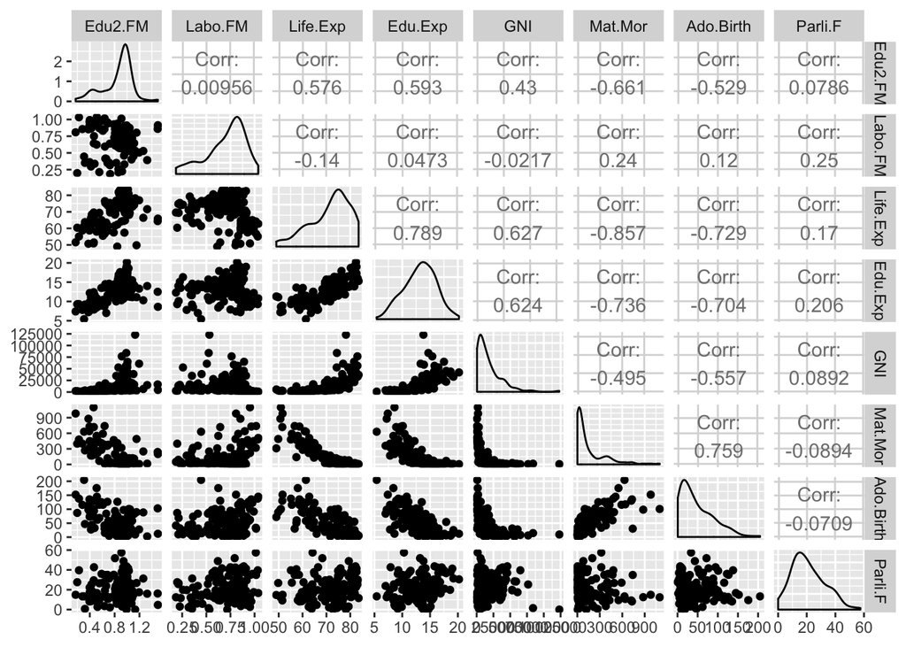

```r
ggpairs(human_)
```

The summaries give an idea about the distributions of the variables: for example, the variables are not scaled here so there are huge differences in the means. This is partly because some of the variables are ratios and others aren’t. Just to point out a couple of things, the summaries show that in the adolescent birth rate the differences between countries are quite staggering and while the median is “only” 33.6, maximum is very much bigger at 204.8. Also, the share of women in parliament is 20.91% on average with a maximum of 57.5% while there is at least one country with zero women in parliament.

Studying the ggpairs()-plot gives a more accurate picture of the data as it plots the data and distributions and shows the correlations between the variables. In short, while the first half of the variables (Edu2.FM, Labo.FM, Life.Exp and Edu.Exp) have negative skewness the latter half is quite heavily positively skewed.

To visualize the correlations more accurately, let’s look at the corrplot() below.

```r
cor(human_)
```

```
##                Edu2.FM      Labo.FM   Life.Exp     Edu.Exp         GNI
## Edu2.FM    1.000000000  0.009564039  0.5760299  0.59325156  0.43030485
## Labo.FM    0.009564039  1.000000000 -0.1400125  0.04732183 -0.02173971
## Life.Exp   0.576029853 -0.140012504  1.0000000  0.78943917  0.62666411
## Edu.Exp    0.593251562  0.047321827  0.7894392  1.00000000  0.62433940
## GNI        0.430304846 -0.021739705  0.6266641  0.62433940  1.00000000
## Mat.Mor   -0.660931770  0.240461075 -0.8571684 -0.73570257 -0.49516234
## Ado.Birth -0.529418415  0.120158862 -0.7291774 -0.70356489 -0.55656208
## Parli.F    0.078635285  0.250232608  0.1700863  0.20608156  0.08920818
##              Mat.Mor  Ado.Birth     Parli.F
## Edu2.FM   -0.6609318 -0.5294184  0.07863528
## Labo.FM    0.2404611  0.1201589  0.25023261
## Life.Exp  -0.8571684 -0.7291774  0.17008631
## Edu.Exp   -0.7357026 -0.7035649  0.20608156
## GNI       -0.4951623 -0.5565621  0.08920818
## Mat.Mor    1.0000000  0.7586615 -0.08944000
## Ado.Birth  0.7586615  1.0000000 -0.07087810
## Parli.F   -0.0894400 -0.0708781  1.00000000
```

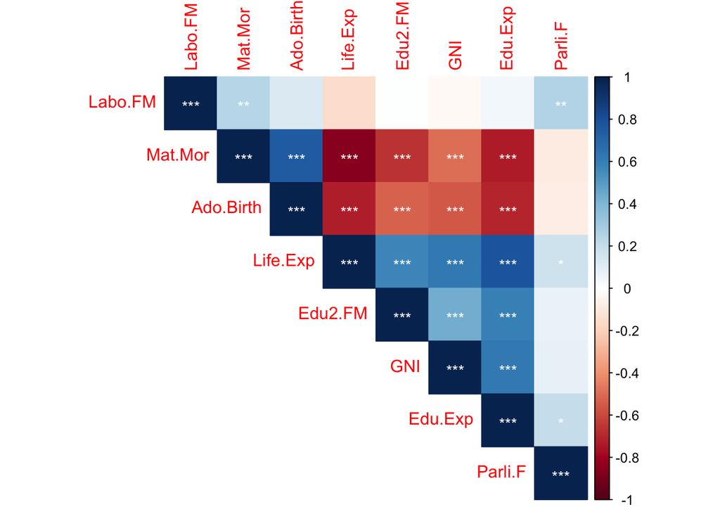

```r
res1 <- cor.mtest(human_, conf.level = .95)
cor(human_) %>% corrplot(p.mat = res1$p, method = "color", type = "upper",
         sig.level = c(.001, .01, .05), pch.cex = .9,
         insig = "label_sig", pch.col = "white", order = "AOE")
```

This visualization shows the correlations between variables. The interpretation is as follows: deep blue color indicates a strong positive correlation and dark red incidates strong negative correlation. The lighter the color, the weaker (closer to zero) the correlation. For example, the share of women in parliament correlates very weakly with other variables as does the ratio of labour force participation of females and males in each country. The strongest positive correlation is between Life.Exp and Edu.Exp (0.79) while the strongest negative correlation is between Mat.Mor and Life.Exp (-0.86).

## Part 2: Principal Component Analysis (PCA) on non-standardized dataset

In this section, I perform principal component analysis (PCA) on the not standardized human data and show the variability captured by the principal components. I also draw a biplot displaying the observations by the first two principal components.

The idea of PCA is explained later in this chapter in Part 4 among the interpretations!

```r
# create and print out a summary of pca_human
pca_human_ <- prcomp(human_)
s <- summary(pca_human_)
s
```

```
## Importance of components:
##                              PC1      PC2   PC3   PC4   PC5   PC6    PC7
## Standard deviation     1.854e+04 185.5219 25.19 11.45 3.766 1.566 0.1912
## Proportion of Variance 9.999e-01   0.0001  0.00  0.00 0.000 0.000 0.0000
## Cumulative Proportion  9.999e-01   1.0000  1.00  1.00 1.000 1.000 1.0000
##                           PC8
## Standard deviation     0.1591
## Proportion of Variance 0.0000
## Cumulative Proportion  1.0000
```

```r
# rounded percetanges of variance captured by each PC
pca_pr <- 100*round(1*s$importance[2, ], digits = 3)

# print out the percentages of variance
pca_pr
```

```
## PC1 PC2 PC3 PC4 PC5 PC6 PC7 PC8
## 100   0   0   0   0   0   0   0
```

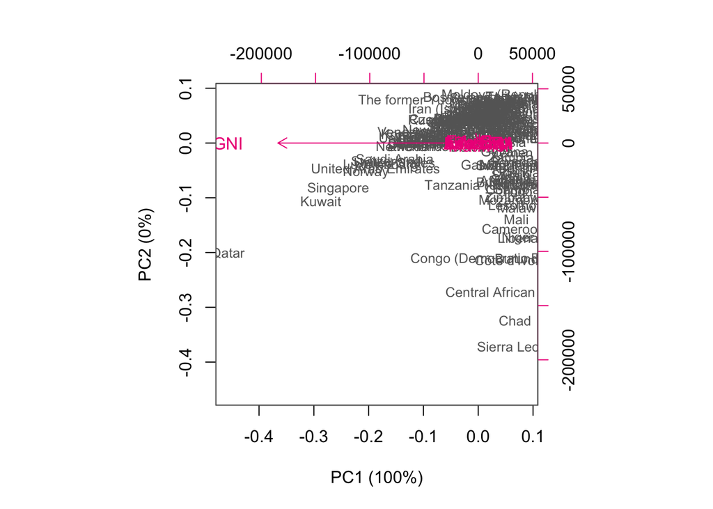

```r
# create object pc_lab to be used as axis labels
pc_lab<-paste0(names(pca_pr), " (", pca_pr, "%)")

# draw a biplot
biplot(pca_human_, cex = c(0.8, 1), col = c("grey40", "deeppink2"), xlab = pc_lab[1], ylab = pc_lab[2])
```

As suggested by the PCA, the first component captures basically all of the variance here. Keep in mind, that the data is not standardized and thus PCA performs very badly. This is due to the staggering differences in the scales of variables: as some of the variables vary in a very small scale in absolute terms, others vary on a much larger scale. Here, the variable GNI is very heavily affecting the PC1. This part illustrates the problems of using PCA without standardizing the data and thus no further meaningful interpretations are provided as they would be very uninformative.

## Part 3: Standardizing the data and performing PCA again + interpretations and comparisons

This section continues working with the PCA after standardizing the data. After running the PCA, I compare the findings to those from Part 2.

```r
# standardize the variables
human_std <- scale(human_)
# print out summaries of the standardized variables
summary(human_std)
```

```
##     Edu2.FM           Labo.FM           Life.Exp          Edu.Exp
##  Min.   :-2.8189   Min.   :-2.6247   Min.   :-2.7188   Min.   :-2.7378
##  1st Qu.:-0.5233   1st Qu.:-0.5484   1st Qu.:-0.6425   1st Qu.:-0.6782
##  Median : 0.3503   Median : 0.2316   Median : 0.3056   Median : 0.1140
##  Mean   : 0.0000   Mean   : 0.0000   Mean   : 0.0000   Mean   : 0.0000
##  3rd Qu.: 0.5958   3rd Qu.: 0.7350   3rd Qu.: 0.6717   3rd Qu.: 0.7126
##  Max.   : 2.6646   Max.   : 1.6632   Max.   : 1.4218   Max.   : 2.4730
##       GNI             Mat.Mor          Ado.Birth          Parli.F
##  Min.   :-0.9193   Min.   :-0.6992   Min.   :-1.1325   Min.   :-1.8203
##  1st Qu.:-0.7243   1st Qu.:-0.6496   1st Qu.:-0.8394   1st Qu.:-0.7409
##  Median :-0.3013   Median :-0.4726   Median :-0.3298   Median :-0.1403
##  Mean   : 0.0000   Mean   : 0.0000   Mean   : 0.0000   Mean   : 0.0000
##  3rd Qu.: 0.3712   3rd Qu.: 0.1932   3rd Qu.: 0.6030   3rd Qu.: 0.6127
##  Max.   : 5.6890   Max.   : 4.4899   Max.   : 3.8344   Max.   : 3.1850
```

```r
# create and print out a summary of pca_human
pca_human <- prcomp(human_std)
s <- summary(pca_human)
s
```

```
## Importance of components:
##                           PC1    PC2     PC3     PC4     PC5     PC6
## Standard deviation     2.0708 1.1397 0.87505 0.77886 0.66196 0.53631
## Proportion of Variance 0.5361 0.1624 0.09571 0.07583 0.05477 0.03595
## Cumulative Proportion  0.5361 0.6984 0.79413 0.86996 0.92473 0.96069
##                            PC7     PC8
## Standard deviation     0.45900 0.32224
## Proportion of Variance 0.02634 0.01298
## Cumulative Proportion  0.98702 1.00000
```

```r
# rounded percetanges of variance captured by each PC
pca_pr <- 100*round(1*s$importance[2, ], digits = 3)

# print out the percentages of variance
pca_pr
```

```
##  PC1  PC2  PC3  PC4  PC5  PC6  PC7  PC8
## 53.6 16.2  9.6  7.6  5.5  3.6  2.6  1.3
```

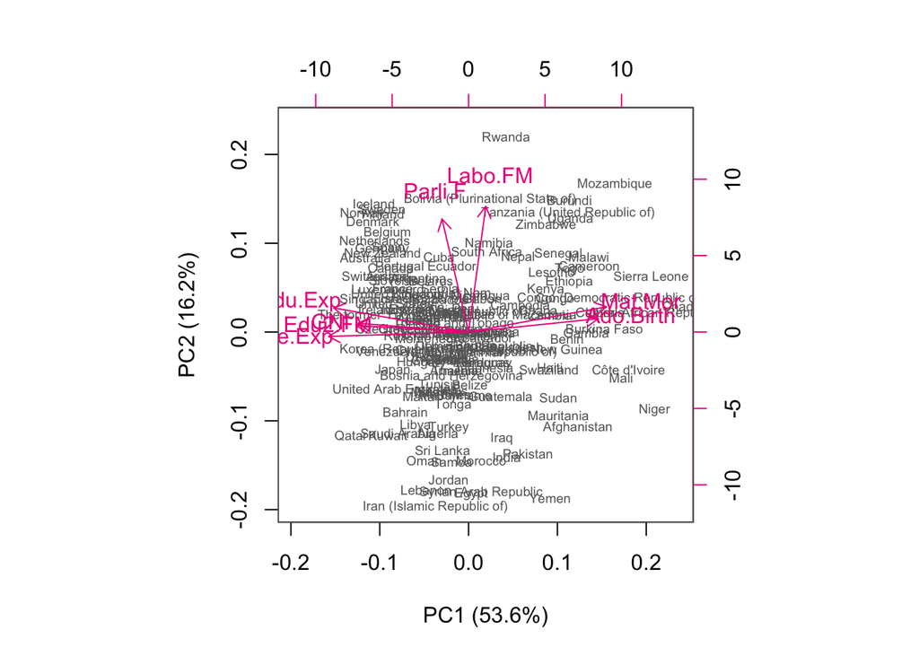

```r
# create object pc_lab to be used as axis labels
pc_lab<-paste0(names(pca_pr), " (", pca_pr, "%)")

# draw a biplot
biplot(pca_human, cex = c(0.6, 1), col = c("grey40", "deeppink2"), xlab = pc_lab[1], ylab = pc_lab[2])
```

Standardizing the data before PCA makes a lot of sense. As explained above in Part 2, the staggering differences in the scales of variables cause a lot of harm unless they are standardized as some of the variables vary in a very small scale in absolute terms while others vary on a much larger scale. PCA is sensitive to the relative scaling of the original features and assumes that features with larger variance are more important than features with smaller variance. This is also the explanation for why the results are very different. Here in the PCA with standardized variables the first principal component (PC1) captures 53.6% of all variation (not 100% like in the non standardized PCA above), the PC2 captures 16.2% and PC3 9.6% of all variation. The latter principal components also capture some variation (around 20% total).

## Part 4: Interpretations of the first two principal component dimensions based on the biplot

The idea of PCA is to reduce the dimensions of the dataset such that it constructs new characteristics that summarize the data in a meaningful way: the new characteristics are constructed such that they explain as much of the variance in the data as possible with the first principal component explaining the more than any other component, the second explaining less than the first but more than the third etc, and the PCs are orthogonal to each other. These new characteristics (the PCs) are constructed using the variables in the dataset.

In other words, the factors heavily defining (although the others also define this as well but not that heavily) PC1 explain most of the variance in the dataset (53.6%) while the second principal component, which explains 16.2% of the variance, is more dominated by Labo.FM and Parli.F. Thus, while the principal components don’t have a straight forward interpretation apart from their statistical properties, the first principal component seems to deal with factors related to development in a broader scale and could be interpreted as a development PC, the second PC is much more closely related to the role of women and therefore could be interpreted as a women PC.